# Exercise 3

21 April 2021

## Game of Thrones

### Season 5 summary in numbers

*Warning:* spoilers ahead

## Overview

- (From the [Wikipedia](https://en.wikipedia.org/wiki/Game_of_Thrones#Premise)) Game of Thrones is an American fantasy drama television series created by David Benioff and D. B. Weiss for HBO. It is an adaptation of A Song of Ice and Fire, a series of fantasy novels by George R. R. Martin, the first of which is A Game of Thrones.
- Set on the fictional continents of Westeros and Essos, Game of Thrones has a large ensemble cast and follows several story arcs throughout the course of the show. A major arc concerns the Iron Throne of the Seven Kingdoms of Westeros through a web of political conflicts among the noble families either vying to claim the throne or fighting for independence from it. Another focuses on the last descendant of the realm’s deposed ruling dynasty, who has been exiled to Essos and is plotting a return to the throne. A third story arc follows the Night’s Watch, a military order defending the realm against threats from the North.

## Season 5 summary

- Season 5 of Game of Thrones consisted of **10 episodes** that aired between April 12 and June 14, 2015 on HBO.
- The show gathered an average of **6.88** first-day TV viewers in the US, with the numbers from **8** to **8.11** million by the end of the season.

## The most popular episode of the season…

… was “Mother’s Mercy”, in which:

“Selyse, now distraught over Shireen’s death, hangs herself, while half of Stannis’ forces desert and Melisandre flees to Castle Black. The Boltons easily defeat Stannis’ depleted army. Brienne finds Stannis on the battlefield and executes him for Renly Baratheon’s murder. Theon kills Myranda after she catches him and Sansa attempting to escape Winterfell. The duo leap from the outer wall together. Cersei confesses her former relationship with Lancel and must atone by parading the streets naked, pelted with garbage, spit, and feces by jeering crowds. Upon reaching the Red Keep, Qyburn introduces her to the newest Kingsguard member who is completely loyal. Jaime, Myrcella, Bronn, and Trystane set sail from Dorne, but Myrcella has been poisoned by Ellaria Sand and soon dies. Arya is punished, losing her sight, for violating the Faceless Men rules after killing Trant for personal revenge. Varys arrives in Meereen to govern the city with Tyrion, Grey Worm, and Missandei, while Daario and Jorah search for Daenerys, who has been captured by a Dothraki horde. Samwell, Gilly, and Little Sam leave Castle Black for Oldtown where Samwell will train as a Maester. Mutineers, including Alliser Thorne and Jon’s steward, Olly, fatally stab Jon, leaving his body in the courtyard.”

## Viewership of the episodes

## Changes during the season

- You can see how the viewership of the episodes changed in figure below.

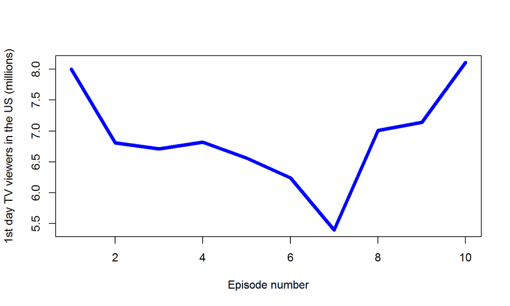

## Above-average episodes

- Finally, the episodes with the above-average viewership were:

| No. in season | Title | Directed by |
| --- | --- | --- |
| 1 | “The Wars to Come” | Michael Slovis |
| 8 | “Hardhome” | Miguel Sapochnik |
| 9 | “The Dance of Dragons” | David Nutter |
| 10 | “Mother’s Mercy” | David Nutter |

## Thank you for your attention!